# Unsupervised Learning

## Algoritma Academy Fugen Night

## Day 1

1. apa itu unsupervised learning ?
- salah satu teknik machine learning yang belajar tanpa kelas target
- Unsupervised biasa digunakan untuk mereduksi dimensi serta melakukan clustering

2.1 dimensionality reduction (menerapkan PCA) - membuat dimensi (variabel) baru yang tujuannya merangkum variabel2 sebelumnya - mereduksi dimensi sebanyak mungkin tapi mempertahankan variansi data sebanyak mungkin - cara PCA bekerja adalah dengan mencari yang namanya eigen vector dan eigen value - nilai eigen vector dan eigen value didapat dari matrix covariance variabel2 yang ada

2.2 fungsi fungsi yang digunakan dalam PCA - scale()

```r
scale_mtcars <- scale(mtcars, center = T, scale = T)
head(scale_mtcars)
```

```
##                          mpg        cyl        disp         hp       drat
## Mazda RX4          0.1508848 -0.1049878 -0.57061982 -0.5350928  0.5675137
## Mazda RX4 Wag      0.1508848 -0.1049878 -0.57061982 -0.5350928  0.5675137
## Datsun 710         0.4495434 -1.2248578 -0.99018209 -0.7830405  0.4739996
## Hornet 4 Drive     0.2172534 -0.1049878  0.22009369 -0.5350928 -0.9661175
## Hornet Sportabout -0.2307345  1.0148821  1.04308123  0.4129422 -0.8351978
## Valiant           -0.3302874 -0.1049878 -0.04616698 -0.6080186 -1.5646078
##                             wt       qsec         vs         am       gear
## Mazda RX4         -0.610399567 -0.7771651 -0.8680278  1.1899014  0.4235542
## Mazda RX4 Wag     -0.349785269 -0.4637808 -0.8680278  1.1899014  0.4235542
## Datsun 710        -0.917004624  0.4260068  1.1160357  1.1899014  0.4235542
## Hornet 4 Drive    -0.002299538  0.8904872  1.1160357 -0.8141431 -0.9318192
## Hornet Sportabout  0.227654255 -0.4637808 -0.8680278 -0.8141431 -0.9318192
## Valiant            0.248094592  1.3269868  1.1160357 -0.8141431 -0.9318192
##                         carb
## Mazda RX4          0.7352031
## Mazda RX4 Wag      0.7352031
## Datsun 710        -1.1221521
## Hornet 4 Drive    -1.1221521
## Hornet Sportabout -0.5030337
## Valiant           -1.1221521
```

fungsi : untuk melakukan scaling terhadap variabel parameter : - data - scale = T - center = T

- prcomp()

```r
prcomp_mtcars <- prcomp(mtcars, scale. = T, center = T)
```

fungsi : untuk membuat PCA parameter : - data - scale = T - center = T apabila data sudah dilakukan scaling dengan fungsi scale maka parameter scale dan center pada fungsi prcomp tidak perlu.

scale = T , center = T (x - mean(data))/sd(data)

- biplot ()

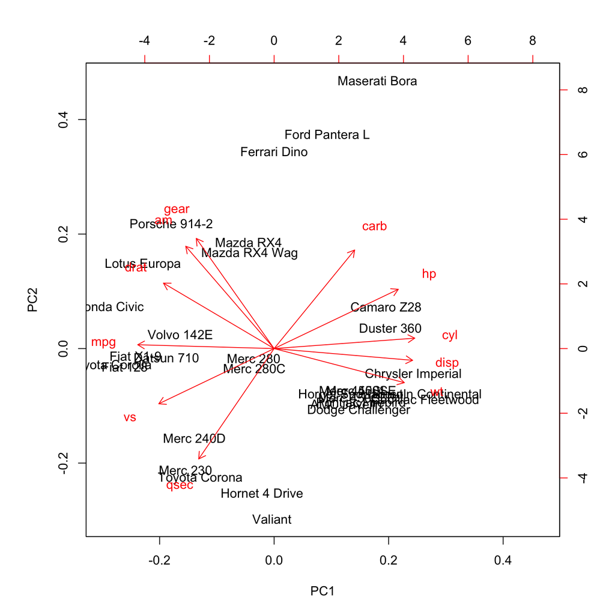

```r
biplot(prcomp_mtcars)
```

fungsi : - biplot merupakan plot untuk memvisualisasikan variabel2 awal berdasarkan PC yang ada - informasi yang bisa didapat dari biplot adalah: 3.1 seberapa pengaruh variabel2 terhadap PC 3.2 seberapa berhubungan variabel2 yang ada 3.3 bisa mendeteksi outlier yang ada (dilihat dari jaraknya terhadap pusat data)

- summary() eigen value = var pc

```r
summary(prcomp_mtcars)
```

```
## Importance of components:
##                           PC1    PC2     PC3     PC4     PC5     PC6
## Standard deviation     2.5707 1.6280 0.79196 0.51923 0.47271 0.46000
## Proportion of Variance 0.6008 0.2409 0.05702 0.02451 0.02031 0.01924
## Cumulative Proportion  0.6008 0.8417 0.89873 0.92324 0.94356 0.96279
##                           PC7     PC8    PC9    PC10   PC11
## Standard deviation     0.3678 0.35057 0.2776 0.22811 0.1485
## Proportion of Variance 0.0123 0.01117 0.0070 0.00473 0.0020
## Cumulative Proportion  0.9751 0.98626 0.9933 0.99800 1.0000
```

```r
#var = sd^2

prcomp_mtcars$sdev^2/ncol(mtcars)
```

```
##  [1] 0.600763659 0.240951627 0.057017934 0.024508858 0.020313737
##  [6] 0.019236011 0.012296544 0.011172858 0.007004241 0.004730495
## [11] 0.002004037
```

```r
cor(prcomp_mtcars$x)
```

```
##                PC1           PC2           PC3           PC4           PC5
## PC1   1.000000e+00 -2.921573e-17 -5.238398e-17 -7.353519e-16 -1.798769e-16
## PC2  -2.921573e-17  1.000000e+00  5.108157e-16 -2.954442e-16 -6.827018e-17
## PC3  -5.238398e-17  5.108157e-16  1.000000e+00 -4.543398e-16  3.090396e-16
## PC4  -7.353519e-16 -2.954442e-16 -4.543398e-16  1.000000e+00 -8.540256e-17
## PC5  -1.798769e-16 -6.827018e-17  3.090396e-16 -8.540256e-17  1.000000e+00
## PC6   4.102746e-16 -1.439760e-16  1.105819e-16 -1.114877e-15 -4.786019e-16
## PC7  -1.536724e-15 -2.670558e-16 -4.973275e-16  1.350444e-16 -5.580385e-16
## PC8   1.266629e-15  3.104278e-16  7.373512e-16 -9.637379e-17  3.562523e-16
## PC9  -5.020868e-16 -3.679227e-16 -1.673444e-16 -2.018663e-17  3.815491e-16
## PC10  1.413311e-15 -6.382828e-16  2.246418e-16  3.111342e-16 -2.573610e-16
## PC11  2.424740e-15 -5.069820e-16  1.510585e-15 -7.057271e-16  6.227611e-16
##                PC6           PC7           PC8           PC9          PC10
## PC1   4.102746e-16 -1.536724e-15  1.266629e-15 -5.020868e-16  1.413311e-15
## PC2  -1.439760e-16 -2.670558e-16  3.104278e-16 -3.679227e-16 -6.382828e-16
## PC3   1.105819e-16 -4.973275e-16  7.373512e-16 -1.673444e-16  2.246418e-16
## PC4  -1.114877e-15  1.350444e-16 -9.637379e-17 -2.018663e-17  3.111342e-16
## PC5  -4.786019e-16 -5.580385e-16  3.562523e-16  3.815491e-16 -2.573610e-16
## PC6   1.000000e+00 -7.352461e-16  4.754787e-17  3.724234e-17 -9.517180e-17
## PC7  -7.352461e-16  1.000000e+00 -6.135851e-17  3.320024e-16 -1.812464e-16
## PC8   4.754787e-17 -6.135851e-17  1.000000e+00 -4.111163e-16  8.549599e-16
## PC9   3.724234e-17  3.320024e-16 -4.111163e-16  1.000000e+00  3.080202e-16
## PC10 -9.517180e-17 -1.812464e-16  8.549599e-16  3.080202e-16  1.000000e+00
## PC11 -1.205061e-15 -1.072338e-16  6.230426e-16 -2.712045e-16  9.937242e-17
##               PC11
## PC1   2.424740e-15
## PC2  -5.069820e-16
## PC3   1.510585e-15
## PC4  -7.057271e-16
## PC5   6.227611e-16
## PC6  -1.205061e-15
## PC7  -1.072338e-16
## PC8   6.230426e-16
## PC9  -2.712045e-16
## PC10  9.937242e-17
## PC11  1.000000e+00
```

```r
#semakin besar nilai eigen value maka nilai variansi dari PC semakin besar
```

rm model saya tidak bisa diinterpretasikan harga rumah = B0 + 1.9 X luas tanah + 0.23 X banyaknya kamar…..

PCA + rm harga rumah = B0 + 2.1 X Pc1 + 3.2 X PC2

day 2

factomineR

PCA() parameter: - x data yang akan digunakan - quali.sup untuk memberi tau var yang factor - graph T/F untuk mengeluarkan plot atau tidak - ncp banyaknya dimensi yang akan di gunakan pada final model

plot.PCA() - x objek dari PCA() - choix ind untuk memvisualisasikan data var untuk memvisualisasikan variabel - habillage untuk memberi warna berdasarkan variabel yang bertipe factor - select contrib x, ingin melihat sebanyak x data yang paling berpengaruh

dimdesc() untuk melihat deskripsi data dimensi yang ada

salah satu karakter dari PCA adalah: 1. antar PC tidak memiliki `cor()` 2. ketika kita sudah membuat objek PCA kita bisa mengembalikannya ke bentuk semula sebanyak dimensi yang kita pilih `reconst()`